# Stunting in Peruvian children aged 6-59 months

Dataset 6: Peru DHS child anaemia and growth extract

RSR feasibility analysis

2026-08-03

# Introduction

Stunting – height-for-age more than two standard deviations below the WHO reference median – is the standard indicator of chronic childhood undernutrition and a strong predictor of later cognitive and economic outcomes. Peru has halved its national stunting prevalence since 2005, but the remaining burden is heavily concentrated in highland and jungle communities and in the poorest households. The Peruvian Demographic and Health Survey (ENDES) measures every surveyed child aged 6-59 months and links the measurement to birth history, maternal characteristics, household wealth and geography.

**Aim.** Among Peruvian children aged 6-59 months, we examined which of child age, child sex, birth-weight category, maternal education, household wealth, natural region and maternal indigenous identity are independently associated with stunting, mutually adjusting for the others.

This is a *Purpose 3* analysis: several predictors are of interest and the question is which remain associated with the outcome after mutual adjustment.

# Methods

**Data source.** A cross-sectional extract of 19191 children aged 6-59 months from the Peru Demographic and Health Survey (ENDES), a nationally implemented household survey, each linked to their mother’s interview and household record.

**Variables.** The outcome is `stunting`, defined as height-for-age Z-score below -2; the modelled event is **stunting = Yes**. Predictors are child age in months (continuous, 6-59); child sex (reference *Female*); maternally reported birth-weight category (reference *Normal*, versus *Low* i.e. below 2.5 kg and *Macrosomia*); mother’s highest education (reference *Primary or none*); household wealth quintile (reference *Poorest*); natural region (reference *Lima metropolitan*); and maternal indigenous identity (reference *No*).

`height_for_age_z` is **excluded by construction**: `stunting` is exactly `height_for_age_z < -2`, so including the Z-score would give a perfectly separating, meaningless model. Haemoglobin and anaemia are also excluded because they are co-outcomes of undernutrition rather than exposures. `survey_weight` is never a predictor.

**Statistical analysis.** Logistic regression via `glm(family = binomial)`, justified because the outcome is binary; estimates are reported as odds ratios. We fitted a univariable model for each predictor first, then a single multivariable model containing all of them. Predictors were chosen in advance on subject-matter grounds, not by significance. Significance threshold 0.05; estimates are reported with 95% confidence intervals. Assumptions were checked with `performance::check_model()`. Analysis used R version 4.6.0 (2026-04-24) with tidyverse, gtsummary and performance.

**Missing data.** Complete-case analysis: 18640 of 19191 rows were analysed (551 dropped, 2.9%). Essentially all the loss is missing maternally reported birth weight.

# Results

## Sample characteristics

**Table 1. Sample characteristics by stunting status.**

| **Characteristic** | **N** | **Overall** N = 18,640<sup>1</sup> | **No** N = 16,360<sup>1</sup> | **Yes** N = 2,280<sup>1</sup> |
| --- | --- | --- | --- | --- |
| Child age (months) | 18,640 | 33 (19, 46) | 33 (19, 47) | 28 (16, 42) |
| Child sex | 18,640 |  |  |  |
| Female |  | 8,997 (48%) | 7,960 (49%) | 1,037 (45%) |
| Male |  | 9,643 (52%) | 8,400 (51%) | 1,243 (55%) |
| Birth-weight category (maternal report) | 18,640 |  |  |  |
| Normal |  | 15,997 (86%) | 14,134 (86%) | 1,863 (82%) |
| Low (<2.5 kg) |  | 1,165 (6.3%) | 815 (5.0%) | 350 (15%) |
| Macrosomia |  | 1,478 (7.9%) | 1,411 (8.6%) | 67 (2.9%) |
| Mother's education | 18,640 |  |  |  |
| Primary or none |  | 3,318 (18%) | 2,499 (15%) | 819 (36%) |
| Secondary |  | 9,312 (50%) | 8,171 (50%) | 1,141 (50%) |
| Higher |  | 6,010 (32%) | 5,690 (35%) | 320 (14%) |
| Household wealth quintile | 18,640 |  |  |  |
| Poorest |  | 5,570 (30%) | 4,194 (26%) | 1,376 (60%) |
| Poorer |  | 5,094 (27%) | 4,572 (28%) | 522 (23%) |
| Middle |  | 3,751 (20%) | 3,520 (22%) | 231 (10%) |
| Richer |  | 2,579 (14%) | 2,470 (15%) | 109 (4.8%) |
| Richest |  | 1,646 (8.8%) | 1,604 (9.8%) | 42 (1.8%) |
| Natural region | 18,640 |  |  |  |
| Lima metropolitan |  | 2,298 (12%) | 2,218 (14%) | 80 (3.5%) |
| Rest of coast |  | 5,446 (29%) | 5,097 (31%) | 349 (15%) |
| Highlands |  | 6,217 (33%) | 5,027 (31%) | 1,190 (52%) |
| Jungle |  | 4,679 (25%) | 4,018 (25%) | 661 (29%) |
| Mother indigenous | 18,640 | 1,794 (9.6%) | 1,255 (7.7%) | 539 (24%) |

<sup>1</sup> Median (Q1, Q3); n (%)

12.2% of children (2280 of 18640) were stunted. The socio-economic concentration is extreme: 24.7% of children in the poorest quintile versus 2.6% in the richest, an approximately 9.5-fold difference in prevalence. Stunted children are also over-represented in the highlands and jungle, in indigenous households and among those reported as low birth weight.

## Exploratory figure

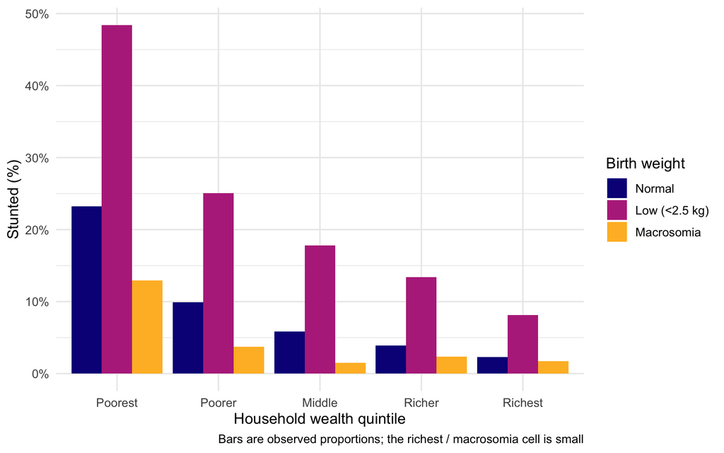

Figure 1. Prevalence of stunting by household wealth quintile and reported birth-weight category.

## Univariable models

| **Characteristic** | **N** | **OR** | **95% CI** | **p-value** |
| --- | --- | --- | --- | --- |
| Child age (months) | 18,640 | 0.99 | 0.98, 0.99 | <0.001 |
| Child sex | 18,640 |  |  |  |
| Female |  | — | — |  |
| Male |  | 1.14 | 1.04, 1.24 | 0.005 |
| Birth-weight category (maternal report) | 18,640 |  |  |  |
| Normal |  | — | — |  |
| Low (<2.5 kg) |  | 3.26 | 2.85, 3.72 | <0.001 |
| Macrosomia |  | 0.36 | 0.28, 0.46 | <0.001 |
| Mother's education | 18,640 |  |  |  |
| Primary or none |  | — | — |  |
| Secondary |  | 0.43 | 0.39, 0.47 | <0.001 |
| Higher |  | 0.17 | 0.15, 0.20 | <0.001 |
| Household wealth quintile | 18,640 |  |  |  |
| Poorest |  | — | — |  |
| Poorer |  | 0.35 | 0.31, 0.39 | <0.001 |
| Middle |  | 0.20 | 0.17, 0.23 | <0.001 |
| Richer |  | 0.13 | 0.11, 0.16 | <0.001 |
| Richest |  | 0.08 | 0.06, 0.11 | <0.001 |
| Natural region | 18,640 |  |  |  |
| Lima metropolitan |  | — | — |  |
| Rest of coast |  | 1.90 | 1.49, 2.45 | <0.001 |
| Highlands |  | 6.56 | 5.24, 8.34 | <0.001 |
| Jungle |  | 4.56 | 3.62, 5.83 | <0.001 |
| Mother indigenous | 18,640 |  |  |  |
| No |  | — | — |  |
| Yes |  | 3.73 | 3.33, 4.17 | <0.001 |

Abbreviations: CI = Confidence Interval, OR = Odds Ratio

Low birth weight is the strongest child-level predictor: reported birth weight under 2.5 kg carries 3.26 times the crude odds of stunting (95% CI 2.85 to 3.72, p < 0.001), while macrosomia is strongly protective (OR 0.36). The social contrasts are larger still: highland residence carries 6.6 times the odds of Lima, maternal indigenous identity 3.7 times, and the richest quintile has 92% lower odds than the poorest. Every predictor including child sex is significant crudely, which at this sample size says little on its own.

## Why adjustment is needed

The crude odds ratios overlap heavily and cannot be read side by side. **Household wealth** confounds the regional and ethnic contrasts: the highlands and jungle contain most of the poorest quintile while Lima contains almost none of it, and poverty independently determines diet, sanitation and health-service access, so a crude highlands OR of 6.6 is substantially a poverty estimate. **Maternal education** does the same for wealth and ethnicity: better-educated mothers live in richer households, are less often indigenous, and independently practise better infant feeding, so schooling and wealth each absorb part of the other’s crude effect. **Birth weight** is itself socially patterned, so the crude birth-weight OR partly reflects the maternal circumstances that produced the small baby. And **child age** matters because stunting prevalence peaks in the second year of life and the age composition is not identical across quintiles or regions. Mutual adjustment is required before any single association can be described as independent.

## Multivariable model

| **Characteristic** | **OR** | **95% CI** | **p-value** |
| --- | --- | --- | --- |
| Child age (months) | 0.99 | 0.98, 0.99 | <0.001 |
| Child sex |  |  |  |
| Female | — | — |  |
| Male | 1.13 | 1.03, 1.24 | 0.011 |
| Birth-weight category (maternal report) |  |  |  |
| Normal | — | — |  |
| Low (<2.5 kg) | 3.18 | 2.75, 3.68 | <0.001 |
| Macrosomia | 0.45 | 0.35, 0.58 | <0.001 |
| Mother's education |  |  |  |
| Primary or none | — | — |  |
| Secondary | 0.62 | 0.55, 0.69 | <0.001 |
| Higher | 0.41 | 0.35, 0.49 | <0.001 |
| Household wealth quintile |  |  |  |
| Poorest | — | — |  |
| Poorer | 0.54 | 0.47, 0.60 | <0.001 |
| Middle | 0.38 | 0.32, 0.45 | <0.001 |
| Richer | 0.31 | 0.25, 0.39 | <0.001 |
| Richest | 0.21 | 0.15, 0.30 | <0.001 |
| Natural region |  |  |  |
| Lima metropolitan | — | — |  |
| Rest of coast | 1.49 | 1.16, 1.93 | 0.002 |
| Highlands | 2.63 | 2.06, 3.40 | <0.001 |
| Jungle | 1.97 | 1.53, 2.55 | <0.001 |
| Mother indigenous |  |  |  |
| No | — | — |  |
| Yes | 1.44 | 1.26, 1.64 | <0.001 |

Abbreviations: CI = Confidence Interval, OR = Odds Ratio

Model fit

| Statistic | Value |
| --- | --- |
| AIC | 11972.5 |
| Null deviance | 13850.2 |
| Residual deviance | 11942.5 |
| Observations | 18640.0 |
| Events (stunting = Yes) | 2280.0 |
| Model parameters (incl. intercept) | 15.0 |
| Events per parameter | 162.9 |

## Unadjusted versus adjusted

**Table 2. Unadjusted and adjusted odds ratios.**

| **Characteristic** | **Unadjusted** **N** | **Unadjusted** **OR** | **Unadjusted** **95% CI** | **Unadjusted** **p-value** | **Adjusted** **OR** | **Adjusted** **95% CI** | **Adjusted** **p-value** |
| --- | --- | --- | --- | --- | --- | --- | --- |
| Child age (months) | 18,640 | 0.99 | 0.98, 0.99 | <0.001 | 0.99 | 0.98, 0.99 | <0.001 |
| Child sex | 18,640 |  |  |  |  |  |  |
| Female |  | — | — |  | — | — |  |
| Male |  | 1.14 | 1.04, 1.24 | 0.005 | 1.13 | 1.03, 1.24 | 0.011 |
| Birth-weight category (maternal report) | 18,640 |  |  |  |  |  |  |
| Normal |  | — | — |  | — | — |  |
| Low (<2.5 kg) |  | 3.26 | 2.85, 3.72 | <0.001 | 3.18 | 2.75, 3.68 | <0.001 |
| Macrosomia |  | 0.36 | 0.28, 0.46 | <0.001 | 0.45 | 0.35, 0.58 | <0.001 |
| Mother's education | 18,640 |  |  |  |  |  |  |
| Primary or none |  | — | — |  | — | — |  |
| Secondary |  | 0.43 | 0.39, 0.47 | <0.001 | 0.62 | 0.55, 0.69 | <0.001 |
| Higher |  | 0.17 | 0.15, 0.20 | <0.001 | 0.41 | 0.35, 0.49 | <0.001 |
| Household wealth quintile | 18,640 |  |  |  |  |  |  |
| Poorest |  | — | — |  | — | — |  |
| Poorer |  | 0.35 | 0.31, 0.39 | <0.001 | 0.54 | 0.47, 0.60 | <0.001 |
| Middle |  | 0.20 | 0.17, 0.23 | <0.001 | 0.38 | 0.32, 0.45 | <0.001 |
| Richer |  | 0.13 | 0.11, 0.16 | <0.001 | 0.31 | 0.25, 0.39 | <0.001 |
| Richest |  | 0.08 | 0.06, 0.11 | <0.001 | 0.21 | 0.15, 0.30 | <0.001 |
| Natural region | 18,640 |  |  |  |  |  |  |
| Lima metropolitan |  | — | — |  | — | — |  |
| Rest of coast |  | 1.90 | 1.49, 2.45 | <0.001 | 1.49 | 1.16, 1.93 | 0.002 |
| Highlands |  | 6.56 | 5.24, 8.34 | <0.001 | 2.63 | 2.06, 3.40 | <0.001 |
| Jungle |  | 4.56 | 3.62, 5.83 | <0.001 | 1.97 | 1.53, 2.55 | <0.001 |
| Mother indigenous | 18,640 |  |  |  |  |  |  |
| No |  | — | — |  | — | — |  |
| Yes |  | 3.73 | 3.33, 4.17 | <0.001 | 1.44 | 1.26, 1.64 | <0.001 |

Abbreviations: CI = Confidence Interval, OR = Odds Ratio

## Diagnostics

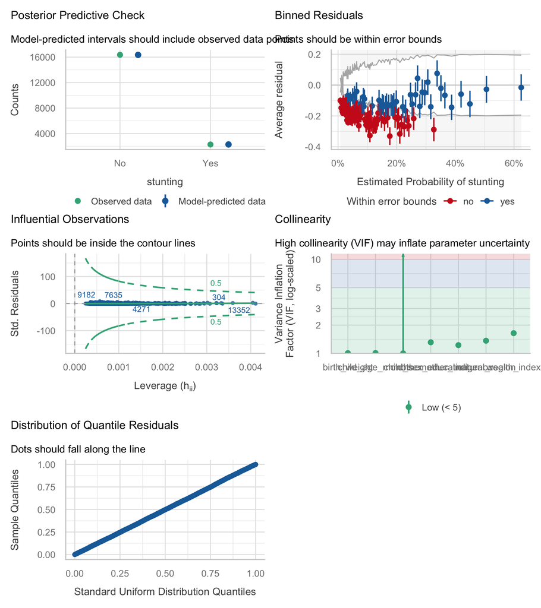

# Discussion

Stunting in Peruvian preschool children is driven jointly by birth endowment and household circumstances. A child reported as low birth weight has about 3.2 times the odds of stunting compared with a normal-birth-weight child of the same sex, age, region, ethnicity, maternal schooling and household wealth – and that estimate is essentially unchanged by adjustment, so it is not merely a marker of poverty. On top of that, moving from the poorest to the richest quintile is associated with roughly 79% lower adjusted odds, and highland residence with about 2.6 times the odds of Lima. Practically this supports a two-pronged approach: antenatal care that reduces low birth weight, and continued postnatal nutrition programming targeted at poor highland and jungle households.

**Limitations.** Cross-sectional design; all estimates are associations, not causal effects. The outcome is a **dichotomised continuous measurement** – the same information analysed on the continuous HAZ scale has more power and does not depend on an arbitrary cut-point, so the continuous analysis should be preferred where possible. Birth weight is a **maternally reported three-level category**, not a measured weight in kilograms, and is therefore subject to recall bias that is likely worse among less-educated mothers, exactly the group with the highest stunting risk; this would bias the birth-weight OR toward the null. The source ENDES analysis used the DHS complex design – cluster (HV001), stratum (HV022) and sampling weights – whereas this extract carries only the weight variable, which is deliberately not used here; standard errors are therefore too narrow, estimates are not design-corrected, and **this sample must not be described as nationally representative**. With 18640 rows almost every comparison is statistically significant, so interpretation must lead with effect sizes rather than p-values. The single strongest known determinant of child height, **maternal height**, is not in this extract at all, and neither are birth order, birth interval, infection history or dietary diversity, so residual confounding is certain. The binned-residual check fails, so the age term is mis-specified. Finally, the 551 rows dropped for missing birth weight are unlikely to be missing completely at random.

**Future work.** Refit with the DHS survey design, an age spline, and maternal height and birth order from the fuller ENDES recode file.

# Feasibility notes

*Not part of a student report.*

- **Works statistically.** 2280 events, 162.9 events per parameter, no separation, maximum VIF 1.64, large and interpretable odds ratios. This is a safe logistic exercise.
- **FATAL trap: the deterministic twin.** `stunting` is *exactly* `height_for_age_z < -2`. Including the Z-score gives perfect separation. This must be flagged in the brief; it is the most likely way a student wrecks this analysis.
- **Redundant with the HAZ outcome.** This is the same question as `height_for_age_z`, run on a coarsened version of the same measurement. Students should do one or the other; the continuous version is statistically better and the binary version is the better logistic-regression *exercise*.
- **Binned residuals fail badly (31.4% within bounds).** Worse than the anaemia model, because the age-stunting relationship is non-monotonic (peak around 18 months). Usable as a teaching point, but a student will need guidance or will simply report that diagnostics were fine.
- **Some thin cells.** Only 67 stunted macrosomic children, and only single-digit stunted counts in the Lima / richest-quintile cell. The main effects model is fine; any interaction with those groups is not.
- **Birth weight is categorical, not kg.** The codebook wording invites students to treat `birth_weight` as continuous. It is a three-level string, and the two non-reference levels point in *opposite* directions.
- **Sample size.** At 18640 rows everything is significant; the brief must force effect-size-led interpretation.
- **Design not honoured.** Only the weight is present, not cluster or stratum, so a design-correct analysis is impossible from this extract.